# metadid Simulation Validation Report

Author

metadid-sims pipeline

Published

May 20, 2026

```r
library(targets)
library(dplyr)
library(ggplot2)
library(knitr)
library(kableExtra)

tar_source("R/scenarios.R")
tar_source("R/plots.R")

all_agg <- tar_read(all_agg)
all_rep <- tar_read(all_rep)
scenario_lookup_tbl <- scenario_lookup()
```

## Executive Summary

```r
# Flag scenarios with empirical coverage below 80% for the treatment effect
poor_coverage <- all_agg |>
  filter(parameter == "treatment_effect_mean", empirical_coverage < 0.80)

convergence_issues <- all_agg |>
  filter(parameter == "treatment_effect_mean", pct_rhat_bad > 0.10)
```

19 scenario(s) had coverage below 80% for the treatment effect mean.

5 scenario(s) had >10% of fits with convergence warnings.

```r
kable(
  poor_coverage |>
    left_join(
      tibble(
        scenario_id = names(SCENARIO_CONFIGS),
        description = purrr::map_chr(SCENARIO_CONFIGS, "description")
      ),
      by = "scenario_id"
    ) |>
    select(scenario_id, description, model_label, empirical_coverage, mean_bias, rmse),
  digits = 3,
  caption = "Scenarios with <80% coverage for treatment_effect_mean"
)
```

Scenarios with <80% coverage for treatment_effect_mean

| scenario_id | description | model_label | empirical_coverage | mean_bias | rmse |
| --- | --- | --- | --- | --- | --- |
| F4 | Large DiD + RCT only: 100 DiD + 100 RCT | default | 0.76 | -0.001 | 0.008 |
| B1 | Naive vs full: PP-heavy, large trend (full should win) | naive | 0.00 | -0.193 | 0.194 |
| B3 | Naive wins: DiD trend = 0, PP trend = -0.10 (pooled borrows wrong trend) | full | 0.24 | -0.089 | 0.093 |
| B3 | Naive wins: DiD trend = 0, PP trend = -0.10 (pooled borrows wrong trend) | naive | 0.00 | -0.114 | 0.116 |
| B5 | RCT baseline imbalance (only in this design): full (estimated) vs naive (fixed zero), 10 DiD + 10 RCT | full | 0.32 | 0.058 | 0.061 |
| B5 | RCT baseline imbalance (only in this design): full (estimated) vs naive (fixed zero), 10 DiD + 10 RCT | naive | 0.08 | 0.068 | 0.070 |
| B6 | DiD imbalance > RCT imbalance: full vs naive, 15 DiD + 15 RCT | full | 0.24 | -0.047 | 0.051 |
| B6 | DiD imbalance > RCT imbalance: full vs naive, 15 DiD + 15 RCT | naive | 0.56 | 0.024 | 0.028 |
| C6 | Asymmetric contamination: outliers all biased in same direction | normal | 0.68 | 0.050 | 0.055 |
| C6 | Asymmetric contamination: outliers all biased in same direction | robust | 0.72 | 0.041 | 0.046 |
| D4 | Effect heterogeneity correlated with sample size | default | 0.00 | 0.126 | 0.127 |
| D5 | Baseline imbalance in RCT with baseline_imbalance=‘fixed_zero’ | default | 0.04 | 0.070 | 0.073 |
| G8 | Jensen’s test: baseline_sd = 0.10, amplified variation (200 DiD) | default | 0.32 | -0.018 | 0.020 |
| H1 | Skewed trends: beta_i ~ -LogNormal (mean = -0.04, log-SD = 1), 15 DiD + 15 PP | naive | 0.08 | -0.061 | 0.066 |
| H2 | Bimodal trends: 50/50 mixture N(-0.10, 0.01) + N(-0.01, 0.01), 15 DiD + 15 PP | naive | 0.16 | -0.063 | 0.067 |
| H3 | Large trend variance: sigma_trend = 0.10 (5x default), 15 DiD + 15 PP | naive | 0.72 | -0.046 | 0.055 |
| H4 | Trend-size confounding: DiD n ~ U(30,70), PP n ~ U(150,250), 15 DiD + 15 PP | full_normal | 0.44 | 0.041 | 0.046 |
| H4 | Trend-size confounding: DiD n ~ U(30,70), PP n ~ U(150,250), 15 DiD + 15 PP | full_robust | 0.40 | 0.041 | 0.047 |
| H4 | Trend-size confounding: DiD n ~ U(30,70), PP n ~ U(150,250), 15 DiD + 15 PP | naive | 0.72 | -0.022 | 0.028 |

## A. Calibration Studies

These scenarios test the model’s core calibration properties — coverage, bias, and RMSE — under a range of study counts, design mixes, and parameterisations. All use the full `meta_did` model unless noted. The baseline scenario (A1) uses 20 DiD studies with default parameters; subsequent scenarios probe how performance changes with sample size (A2–A4), mixed designs (A5–A6), covariates (A7), correlated effects (A8), unnormalised fitting (A9–A10), individual-level data (A11–A12), rho estimation strategies (A13), and sign/direction variants (A14–A18).

```r
scenario_summary_table("A") |>
  kable(caption = "Category A: scenario definitions")
```

Category A: scenario definitions

| ID | Description | DGP overrides | Fit overrides |
| --- | --- | --- | --- |
| A1 | Baseline: DiD-only summary, normalised, 20 studies | (defaults) | (defaults) |
| A2 | Large sample: DiD-only, 60 studies | n_did = 60 | (defaults) |
| A3 | Small sample: DiD-only, 5 studies | n_did = 5 | (defaults) |
| A4 | Very large sample: DiD-only, 200 studies | n_did = 200 | (defaults) |
| A5 | Mixed designs: 10 DiD + 10 RCT + 10 PP, normalised | n_did = 10; n_rct = 10; n_pp = 10 | (defaults) |
| A6 | PP-heavy with trend: 5 DiD + 25 PP, trend = -0.10 | n_did = 5; n_pp = 25; true_trend = -0.1; sigma_trend = 0.01 | (defaults) |
| A7 | Covariates: 30 DiD studies with dose covariate | n_did = 30 | (defaults) |
| A8 | Correlated effects: 30 DiD, rho_effect_trend = 0.95 | n_did = 30; baseline_sd = 0; rho_effect_trend = 0.95 | fn = meta_did_general; correlated_effects = [TRUE] |
| A9 | Unnormalised DiD-only, 20 studies, raw scale | (defaults) | normalise_by_baseline = [FALSE] |
| A10 | Unnormalised mixed: 10 DiD + 10 RCT + 10 PP, raw scale | n_did = 10; n_rct = 10; n_pp = 10 | normalise_by_baseline = [FALSE] |
| A11 | Individual-level DiD: fit from individual data, 20 studies | (defaults) | data_format = individual |
| A12 | Individual vs summary consistency: same data, fit both ways, 20 studies | (defaults) | (defaults) |
| A13 | Known vs hierarchical rho: same DiD data, compare rho modes | (defaults) | (defaults) |
| A14 | Positive effect: true_effect = +0.15, trend = -0.04 | true_effect = 0.15 | (defaults) |
| A15 | Null effect: true_effect = 0, trend = -0.04 | true_effect = 0 | (defaults) |
| A16 | Positive trend: true_effect = -0.15, trend = +0.04 | true_trend = 0.04 | (defaults) |
| A17 | Sign mismatch: negative effect (-0.15) with positive trend (+0.04), PP-heavy | n_did = 10; n_pp = 20; true_trend = 0.04 | (defaults) |
| A18 | Both positive: true_effect = +0.15, trend = +0.04 | true_effect = 0.15; true_trend = 0.04 | (defaults) |

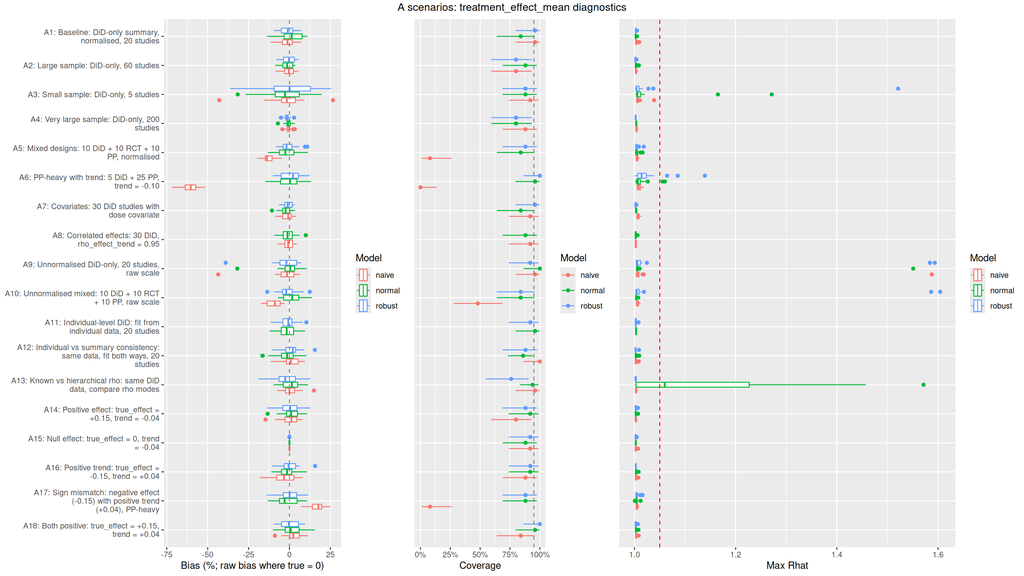

```r
A_combined    <- tar_read(A_combined)
A_agg_combined <- tar_read(A_agg_combined)
plot_diagnostics(A_combined, A_agg_combined, scenario_lookup_tbl, "A")
```

```r
results_table(all_agg, scenario_lookup_tbl, "A")
```

Category A: results

| Scenario | Description | Model | Fit | Parameter | Coverage | Bias | RMSE |
| --- | --- | --- | --- | --- | --- | --- | --- |
| A1 | Baseline: DiD-only summary, normalised, 20 studies | normalised; normal heterogeneity; pooled trend; estimated imbalance | default | time_trend_mean | 1.00 | -0.002 | 0.009 |
|  |  |  | default | time_trend_sd | 0.92 | 0.004 | 0.010 |
|  |  |  | default | treatment_effect_mean | 0.84 | 0.005 | 0.024 |
|  |  |  | default | treatment_effect_sd | 0.80 | 0.016 | 0.021 |
| A2 | Large sample: DiD-only, 60 studies |  | default | time_trend_mean | 0.84 | -0.002 | 0.007 |
|  |  |  | default | time_trend_sd | 0.72 | 0.005 | 0.007 |
|  |  |  | default | treatment_effect_mean | 0.88 | -0.005 | 0.012 |
|  |  |  | default | treatment_effect_sd | 0.60 | 0.013 | 0.016 |
| A3 | Small sample: DiD-only, 5 studies |  | default | time_trend_mean | 1.00 | -0.002 | 0.022 |
|  |  |  | default | time_trend_sd | 0.88 | 0.026 | 0.040 |
|  |  |  | default | treatment_effect_mean | 0.88 | -0.008 | 0.043 |
|  |  |  | default | treatment_effect_sd | 0.80 | 0.041 | 0.063 |
| A4 | Very large sample: DiD-only, 200 studies |  | default | time_trend_mean | 0.96 | -0.001 | 0.003 |
|  |  |  | default | time_trend_sd | 0.64 | 0.004 | 0.005 |
|  |  |  | default | treatment_effect_mean | 0.80 | -0.003 | 0.007 |
|  |  |  | default | treatment_effect_sd | 0.28 | 0.012 | 0.014 |
| A5 | Mixed designs: 10 DiD + 10 RCT + 10 PP, normalised |  | default | time_trend_mean | 0.96 | -0.006 | 0.016 |
|  |  |  | default | time_trend_sd | 0.72 | 0.015 | 0.022 |
|  |  |  | default | treatment_effect_mean | 0.84 | -0.006 | 0.022 |
|  |  |  | default | treatment_effect_sd | 0.64 | 0.018 | 0.024 |
| A6 | PP-heavy with trend: 5 DiD + 25 PP, trend = -0.10 |  | default | time_trend_mean | 1.00 | -0.006 | 0.015 |
|  |  |  | default | time_trend_sd | 0.64 | 0.025 | 0.032 |
|  |  |  | default | treatment_effect_mean | 0.96 | 0.000 | 0.023 |
|  |  |  | default | treatment_effect_sd | 0.80 | 0.012 | 0.022 |
| A7 | Covariates: 30 DiD studies with dose covariate |  | default | beta_cov[dose] | 0.80 | 0.004 | 0.024 |
|  |  |  | default | time_trend_mean | 1.00 | 0.001 | 0.007 |
|  |  |  | default | time_trend_sd | 0.76 | 0.004 | 0.011 |
|  |  |  | default | treatment_effect_mean | 0.84 | -0.013 | 0.023 |
|  |  |  | default | treatment_effect_sd | 0.16 | 0.035 | 0.039 |
| A8 | Correlated effects: 30 DiD, rho_effect_trend = 0.95 | normalised; normal heterogeneity; correlated effects; pooled trend; estimated imbalance | default | time_trend_mean | 0.84 | 0.000 | 0.010 |

[output cut: 53 more lines]

## F. Large-N Bias Probes

These scenarios use large numbers of studies (200 total) to narrow posteriors and expose any systematic bias that would be obscured in smaller samples. They vary the design mix, normalisation strategy, and model specification, allowing a stringent test of whether the model is asymptotically unbiased.

```r
scenario_summary_table("F") |>
  kable(caption = "Category F: scenario definitions")
```

Category F: scenario definitions

| ID | Description | DGP overrides | Fit overrides |
| --- | --- | --- | --- |
| F1 | Large mixed, normalised, full model: 70 DiD + 70 RCT + 60 PP | n_did = 70; n_rct = 70; n_pp = 60 | (defaults) |
| F2 | Large mixed, normalised, naive: 70 DiD + 70 RCT + 60 PP (zero trend, equal baselines) | n_did = 70; n_rct = 70; n_pp = 60; true_trend = 0; sigma_trend = 0; baseline_sd = 0 | fn = meta_did_general; time_trend = fixed_zero; baseline_imbalance = fixed_zero |
| F3 | Large mixed, unnormalised: 70 DiD + 70 RCT + 60 PP | n_did = 70; n_rct = 70; n_pp = 60 | normalise_by_baseline = [FALSE] |
| F4 | Large DiD + RCT only: 100 DiD + 100 RCT | n_did = 100; n_rct = 100 | (defaults) |
| F5 | Large DiD + PP only: 100 DiD + 100 PP, nonzero trend | n_did = 100; n_pp = 100; true_trend = -0.1; sigma_trend = 0.01 | (defaults) |
| F6 | Large DiD-only with covariates: 200 studies | n_did = 200 | (defaults) |
| F7 | Large mixed, design effects: 70 DiD + 70 RCT + 60 PP with offsets | n_did = 70; n_rct = 70; n_pp = 60 | design_effects = [TRUE] |
| F8 | Large DiD-only, correlated effects: 200 studies, rho_effect_trend = 0.95 | n_did = 200; baseline_sd = 0; rho_effect_trend = 0.95 | fn = meta_did_general; correlated_effects = [TRUE] |

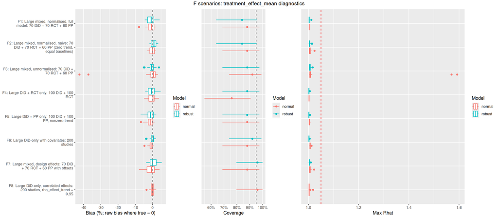

```r
F_combined     <- tar_read(F_combined)
F_agg_combined <- tar_read(F_agg_combined)
plot_diagnostics(F_combined, F_agg_combined, scenario_lookup_tbl, "F")
```

```r
results_table(all_agg, scenario_lookup_tbl, "F")
```

Category F: results

| Scenario | Description | Model | Fit | Parameter | Coverage | Bias | RMSE |
| --- | --- | --- | --- | --- | --- | --- | --- |
| F1 | Large mixed, normalised, full model: 70 DiD + 70 RCT + 60 PP | normalised; normal heterogeneity; pooled trend; estimated imbalance | default | time_trend_mean | 0.96 | -0.001 | 0.005 |
|  |  |  | default | time_trend_sd | 0.80 | 0.003 | 0.006 |
|  |  |  | default | treatment_effect_mean | 0.88 | -0.003 | 0.008 |
|  |  |  | default | treatment_effect_sd | 0.16 | 0.013 | 0.014 |
| F2 | Large mixed, normalised, naive: 70 DiD + 70 RCT + 60 PP (zero trend, equal baselines) | normalised; normal heterogeneity; zero trend; zero imbalance | default | time_trend_mean | 0.72 | 0.000 | 0.005 |
|  |  |  | default | time_trend_sd | 0.00 | 0.011 | 0.012 |
|  |  |  | default | treatment_effect_mean | 0.88 | -0.001 | 0.005 |
|  |  |  | default | treatment_effect_sd | 0.96 | 0.000 | 0.004 |
| F3 | Large mixed, unnormalised: 70 DiD + 70 RCT + 60 PP | unnormalised; normal heterogeneity; pooled trend; estimated imbalance | default | baseline_control_mean | 0.92 | -0.009 | 0.032 |
|  |  |  | default | time_trend_mean | 0.92 | 0.007 | 0.023 |
|  |  |  | default | time_trend_sd | 1.00 | 0.003 | 0.007 |
|  |  |  | default | treatment_effect_mean | 0.92 | -0.004 | 0.017 |
|  |  |  | default | treatment_effect_sd | 0.84 | 0.001 | 0.003 |
| F4 | Large DiD + RCT only: 100 DiD + 100 RCT | normalised; normal heterogeneity; pooled trend; estimated imbalance | default | time_trend_mean | 0.88 | -0.003 | 0.005 |
|  |  |  | default | time_trend_sd | 0.72 | 0.005 | 0.006 |
|  |  |  | default | treatment_effect_mean | 0.76 | -0.001 | 0.008 |
|  |  |  | default | treatment_effect_sd | 0.28 | 0.011 | 0.013 |
| F5 | Large DiD + PP only: 100 DiD + 100 PP, nonzero trend |  | default | time_trend_mean | 0.80 | -0.003 | 0.006 |
|  |  |  | default | time_trend_sd | 0.00 | 0.016 | 0.016 |
|  |  |  | default | treatment_effect_mean | 0.88 | -0.005 | 0.008 |
|  |  |  | default | treatment_effect_sd | 0.04 | 0.020 | 0.021 |
| F6 | Large DiD-only with covariates: 200 studies |  | default | beta_cov[dose] | 0.88 | -0.001 | 0.009 |
|  |  |  | default | time_trend_mean | 0.96 | -0.001 | 0.003 |
|  |  |  | default | time_trend_sd | 0.68 | 0.004 | 0.005 |
|  |  |  | default | treatment_effect_mean | 0.88 | -0.006 | 0.009 |
|  |  |  | default | treatment_effect_sd | 0.00 | 0.030 | 0.030 |
| F7 | Large mixed, design effects: 70 DiD + 70 RCT + 60 PP with offsets | normalised; normal heterogeneity; design effects; pooled trend; estimated imbalance | default | time_trend_mean | 0.92 | -0.003 | 0.007 |
|  |  |  | default | time_trend_sd | 0.84 | 0.005 | 0.006 |
|  |  |  | default | treatment_effect_mean | 0.88 | -0.003 | 0.011 |
|  |  |  | default | treatment_effect_mean_pp | 0.00 | 0.174 | 0.174 |
|  |  |  | default | treatment_effect_mean_rct | 0.00 | -0.223 | 0.224 |
|  |  |  | default | treatment_effect_sd | 0.20 | 0.014 | 0.015 |
| F8 | Large DiD-only, correlated effects: 200 studies, rho_effect_trend = 0.95 | normalised; normal heterogeneity; correlated effects; pooled trend; estimated imbalance | default | time_trend_mean | 0.96 | 0.000 | 0.003 |
|  |  |  | default | time_trend_sd | 0.84 | 0.001 | 0.003 |
|  |  |  | default | treatment_effect_mean | 0.96 | 0.000 | 0.004 |
|  |  |  | default | treatment_effect_sd | 0.92 | 0.002 | 0.004 |

## B. Comparative Studies

These scenarios pit two model configurations against each other on the same simulated data, asking which recovers the treatment effect better under specific conditions. Each scenario has a clear hypothesis about which model should win (or whether they should tie).

```r
scenario_summary_table("B") |>
  kable(caption = "Category B: scenario definitions")
```

Category B: scenario definitions

| ID | Description | DGP overrides | Fit overrides |
| --- | --- | --- | --- |
| B1 | Naive vs full: PP-heavy, large trend (full should win) | n_did = 5; n_pp = 25; true_trend = -0.1; sigma_trend = 0.01 | (defaults) |
| B2 | Naive vs full: assumptions satisfied (zero trend, equal baselines) | n_did = 10; n_rct = 10; n_pp = 10; true_trend = 0; sigma_trend = 0; baseline_sd = 0 | (defaults) |
| B3 | Naive wins: DiD trend = 0, PP trend = -0.10 (pooled borrows wrong trend) | n_did = 10; n_pp = 10; did_trend = 0; pp_trend = -0.1 | (defaults) |
| B4 | Correlated vs independent effects: rho_effect_trend = 0.95 | n_did = 30; baseline_sd = 0; rho_effect_trend = 0.95 | (defaults) |
| B5 | RCT baseline imbalance (only in this design): full (estimated) vs naive (fixed zero), 10 DiD + 10 RCT | n_did = 10; n_rct = 10; rct_gamma_mean = 0.05; rct_gamma_sd = 0.02 | (defaults) |
| B6 | DiD imbalance > RCT imbalance: full vs naive, 15 DiD + 15 RCT | n_did = 15; n_rct = 15; did_gamma_mean = 0.08; did_gamma_sd = 0.02; rct_gamma_mean = 0.01; rct_gamma_sd = 0.01 | (defaults) |

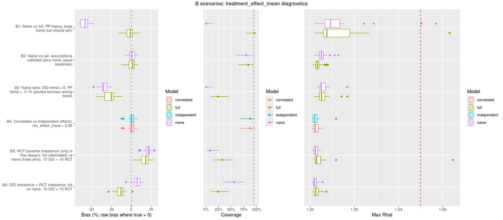

```r
plot_diagnostics(all_rep, all_agg, scenario_lookup_tbl, "B")
```

```r
results_table(all_agg, scenario_lookup_tbl, "B")
```

Category B: results

| Scenario | Description | Model | Fit | Parameter | Coverage | Bias | RMSE |
| --- | --- | --- | --- | --- | --- | --- | --- |
| B1 | Naive vs full: PP-heavy, large trend (full should win) | normalised; normal heterogeneity; pooled trend; estimated imbalance | full | time_trend_mean | 0.84 | -0.001 | 0.020 |
|  |  |  | full | time_trend_sd | 0.64 | 0.030 | 0.038 |
|  |  |  | full | treatment_effect_mean | 0.96 | -0.005 | 0.025 |
|  |  |  | full | treatment_effect_sd | 0.76 | 0.013 | 0.025 |
|  |  |  | naive | time_trend_mean | 0.96 | 0.005 | 0.021 |
|  |  |  | naive | time_trend_sd | 0.80 | 0.033 | 0.044 |
|  |  |  | naive | treatment_effect_mean | 0.00 | -0.193 | 0.194 |
|  |  |  | naive | treatment_effect_sd | 0.00 | 0.065 | 0.068 |
| B2 | Naive vs full: assumptions satisfied (zero trend, equal baselines) |  | full | time_trend_mean | 0.96 | -0.003 | 0.009 |
|  |  |  | full | time_trend_sd | 0.00 | 0.018 | 0.019 |
|  |  |  | full | treatment_effect_mean | 0.84 | 0.002 | 0.018 |
|  |  |  | full | treatment_effect_sd | 0.84 | -0.001 | 0.013 |
|  |  |  | naive | time_trend_mean | 1.00 | -0.004 | 0.008 |
|  |  |  | naive | time_trend_sd | 0.00 | 0.018 | 0.019 |
|  |  |  | naive | treatment_effect_mean | 0.80 | 0.003 | 0.015 |
|  |  |  | naive | treatment_effect_sd | 0.80 | 0.004 | 0.013 |
| B3 | Naive wins: DiD trend = 0, PP trend = -0.10 (pooled borrows wrong trend) |  | full | time_trend_mean | 0.36 | 0.063 | 0.068 |
|  |  |  | full | time_trend_sd | 0.92 | 0.015 | 0.027 |
|  |  |  | full | treatment_effect_mean | 0.24 | -0.089 | 0.093 |
|  |  |  | full | treatment_effect_sd | 0.20 | 0.068 | 0.072 |
|  |  |  | naive | time_trend_mean | 0.00 | 0.088 | 0.089 |
|  |  |  | naive | time_trend_sd | 0.96 | 0.005 | 0.013 |
|  |  |  | naive | treatment_effect_mean | 0.00 | -0.114 | 0.116 |
|  |  |  | naive | treatment_effect_sd | 0.00 | 0.088 | 0.090 |
| B4 | Correlated vs independent effects: rho_effect_trend = 0.95 |  | correlated | time_trend_mean | 0.88 | 0.000 | 0.010 |
|  |  |  | correlated | time_trend_sd | 0.92 | 0.002 | 0.008 |
|  |  |  | correlated | treatment_effect_mean | 0.88 | 0.003 | 0.015 |
|  |  |  | correlated | treatment_effect_sd | 0.92 | 0.004 | 0.012 |
|  |  |  | independent | time_trend_mean | 0.88 | 0.000 | 0.010 |
|  |  |  | independent | time_trend_sd | 0.84 | 0.006 | 0.010 |
|  |  |  | independent | treatment_effect_mean | 0.88 | 0.003 | 0.015 |
|  |  |  | independent | treatment_effect_sd | 0.84 | 0.010 | 0.015 |
| B5 | RCT baseline imbalance (only in this design): full (estimated) vs naive (fixed zero), 10 DiD + 10 RCT |  | full | time_trend_mean | 0.84 | 0.003 | 0.019 |
|  |  |  | full | time_trend_sd | 0.80 | 0.005 | 0.020 |
|  |  |  | full | treatment_effect_mean | 0.32 | 0.058 | 0.061 |
|  |  |  | full | treatment_effect_sd | 0.44 | 0.034 | 0.042 |
|  |  |  | naive | time_trend_mean | 0.84 | 0.003 | 0.019 |
|  |  |  | naive | time_trend_sd | 0.80 | 0.005 | 0.021 |
|  |  |  | naive | treatment_effect_mean | 0.08 | 0.068 | 0.070 |
|  |  |  | naive | treatment_effect_sd | 0.16 | 0.041 | 0.045 |
| B6 | DiD imbalance > RCT imbalance: full vs naive, 15 DiD + 15 RCT |  | full | time_trend_mean | 0.96 | 0.001 | 0.009 |
|  |  |  | full | time_trend_sd | 0.92 | 0.008 | 0.013 |
|  |  |  | full | treatment_effect_mean | 0.24 | -0.047 | 0.051 |
|  |  |  | full | treatment_effect_sd | 0.72 | 0.021 | 0.024 |
|  |  |  | naive | time_trend_mean | 0.96 | 0.004 | 0.011 |
|  |  |  | naive | time_trend_sd | 0.92 | 0.009 | 0.013 |
|  |  |  | naive | treatment_effect_mean | 0.56 | 0.024 | 0.028 |
|  |  |  | naive | treatment_effect_sd | 0.72 | 0.018 | 0.020 |

## C. Outlier and Heavy-Tailed Studies

These scenarios test robustness to departures from Gaussian study-level heterogeneity. The contaminating distributions are chosen to be detectable but not catastrophic, so that a robust model (Student-t heterogeneity) should outperform the normal model without being trivially obvious.

```r
scenario_summary_table("C") |>
  kable(caption = "Category C: scenario definitions")
```

Category C: scenario definitions

| ID | Description | DGP overrides | Fit overrides |
| --- | --- | --- | --- |
| C1 | Single outlier: one study shifted by 5*sigma_effect | n_outlier = 1; outlier_shift = 5 | (defaults) |
| C2 | Multiple outliers: 3 of 20 from contaminating distribution | n_outlier = 3; outlier_shift = 5 | (defaults) |
| C3 | Heavy-tailed study effects: theta_i ~ t(df=3) | effect_df = 3 | (defaults) |
| C4 | Heavy-tailed within-study errors: observations ~ t(df=5) | within_df = 5 | (defaults) |
| C5 | Outlier + small sample: single outlier among 5 studies | n_did = 5; n_outlier = 1; outlier_shift = 5 | (defaults) |
| C6 | Asymmetric contamination: outliers all biased in same direction | n_outlier = 3; outlier_shift = 5; outlier_direction = positive | (defaults) |
| C7 | Outlier in one design: 10 DiD + 10 PP, outliers only among PP | n_did = 10; n_pp = 10; n_outlier_pp = 2; outlier_shift = 5 | (defaults) |
| C8 | Heavy-tailed time trends: beta_i ~ t(df=3) | trend_df = 3 | (defaults) |

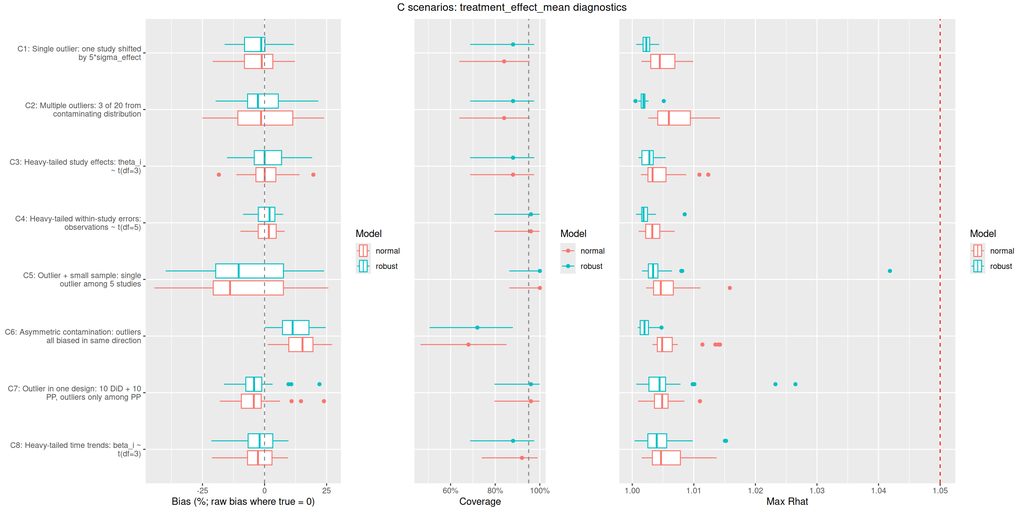

```r
plot_diagnostics(all_rep, all_agg, scenario_lookup_tbl, "C")
```

```r
results_table(all_agg, scenario_lookup_tbl, "C")
```

Category C: results

[output not shown]

## D. Assumption Violation Studies

These scenarios introduce deliberate mismatches between the DGP and the fitted model to quantify the cost of specific assumption violations — unmodelled design effects, heterogeneous within-study variance, misspecified rho, effect-size/sample-size correlation, and ignored RCT baseline imbalance.

```r
scenario_summary_table("D") |>
  kable(caption = "Category D: scenario definitions")
```

Category D: scenario definitions

| ID | Description | DGP overrides | Fit overrides |
| --- | --- | --- | --- |
| D1 | Design-specific effects ignored: RCT/PP shifted, design_effects=FALSE | n_did = 10; n_rct = 10; n_pp = 10; delta_rct = 0.1; delta_pp = -0.08 | (defaults) |
| D2 | Heterogeneous within-study variance: sigma_within drawn from Gamma | within_sd_shape = 4; within_sd_rate = 33.3333333333333 | (defaults) |
| D3 | Misspecified rho: true rho varies by study (Beta distribution) | rho_alpha = 5; rho_beta = 5 | (defaults) |
| D4 | Effect heterogeneity correlated with sample size | size_effect_slope = 0.001 | (defaults) |
| D5 | Baseline imbalance in RCT with baseline_imbalance=‘fixed_zero’ | n_did = 10; n_rct = 10; rct_gamma_mean = 0.05; rct_gamma_sd = 0.02 | fn = meta_did_general; baseline_imbalance = fixed_zero |

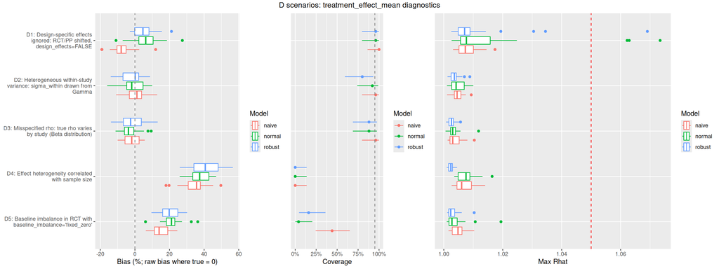

```r
D_combined     <- tar_read(D_combined)
D_agg_combined <- tar_read(D_agg_combined)
plot_diagnostics(D_combined, D_agg_combined, scenario_lookup_tbl, "D")
```

```r
results_table(all_agg, scenario_lookup_tbl, "D")
```

Category D: results

| Scenario | Description | Model | Fit | Parameter | Coverage | Bias | RMSE |
| --- | --- | --- | --- | --- | --- | --- | --- |
| D1 | Design-specific effects ignored: RCT/PP shifted, design_effects=FALSE | normalised; normal heterogeneity; pooled trend; estimated imbalance | default | time_trend_mean | 0.84 | -0.024 | 0.034 |
|  |  |  | default | time_trend_sd | 0.72 | 0.029 | 0.040 |
|  |  |  | default | treatment_effect_mean | 0.96 | 0.021 | 0.033 |
|  |  |  | default | treatment_effect_sd | 0.32 | 0.094 | 0.100 |
| D2 | Heterogeneous within-study variance: sigma_within drawn from Gamma |  | default | time_trend_mean | 0.96 | -0.003 | 0.012 |
|  |  |  | default | time_trend_sd | 0.80 | 0.006 | 0.012 |
|  |  |  | default | treatment_effect_mean | 0.92 | -0.002 | 0.021 |
|  |  |  | default | treatment_effect_sd | 0.72 | 0.013 | 0.022 |
| D3 | Misspecified rho: true rho varies by study (Beta distribution) |  | default | time_trend_mean | 0.96 | 0.000 | 0.009 |
|  |  |  | default | time_trend_sd | 0.68 | 0.004 | 0.015 |
|  |  |  | default | treatment_effect_mean | 0.88 | -0.010 | 0.020 |
|  |  |  | default | treatment_effect_sd | 0.72 | 0.016 | 0.022 |
| D4 | Effect heterogeneity correlated with sample size |  | default | time_trend_mean | 0.92 | -0.004 | 0.012 |
|  |  |  | default | time_trend_sd | 0.76 | 0.010 | 0.014 |
|  |  |  | default | treatment_effect_mean | 0.00 | 0.126 | 0.127 |
|  |  |  | default | treatment_effect_sd | 0.00 | 0.084 | 0.087 |
| D5 | Baseline imbalance in RCT with baseline_imbalance='fixed_zero' | normalised; normal heterogeneity; pooled trend; zero imbalance | default | time_trend_mean | 0.88 | 0.001 | 0.018 |
|  |  |  | default | time_trend_sd | 0.68 | 0.016 | 0.028 |
|  |  |  | default | treatment_effect_mean | 0.04 | 0.070 | 0.073 |
|  |  |  | default | treatment_effect_sd | 0.12 | 0.044 | 0.048 |

## E. Edge Cases

These scenarios probe boundary conditions: extreme pre-post correlations, zero heterogeneity, very large heterogeneity, unbalanced arms, single studies per design, and missing rho values. They test whether the model remains stable and well-calibrated when inputs approach the limits of the assumed data-generating regime.

```r
scenario_summary_table("E") |>
  kable(caption = "Category E: scenario definitions")
```

Category E: scenario definitions

| ID | Description | DGP overrides | Fit overrides |
| --- | --- | --- | --- |
| E1 | Extreme rho: pre-post correlation near 0 and near 1 | rho_values = [0.02, 0.98] | (defaults) |
| E2 | Zero heterogeneity: all studies have identical true effect | sigma_effect = 0; sigma_trend = 0; baseline_sd = 0 | (defaults) |
| E3 | Large heterogeneity: tau >> typical effect size | sigma_effect = 0.3; sigma_trend = 0.1 | (defaults) |
| E4 | Unbalanced arms: n_treatment = 200, n_control = 30 | n_control = 30; n_treatment = 200 | (defaults) |
| E5 | Single study per design: 1 DiD + 1 RCT + 1 PP | n_did = 1; n_rct = 1; n_pp = 1 | (defaults) |
| E6 | Missing rho: hierarchical_rho imputes | (defaults) | provide_rho = [FALSE] |

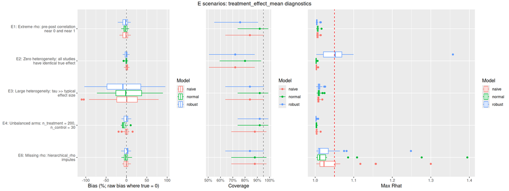

```r
E_combined     <- tar_read(E_combined)
E_agg_combined <- tar_read(E_agg_combined)
plot_diagnostics(E_combined, E_agg_combined, scenario_lookup_tbl, "E", exclude = "E5")
```

```r
results_table(all_agg, scenario_lookup_tbl, "E")
```

Category E: results

| Scenario | Description | Model | Fit | Parameter | Coverage | Bias | RMSE |
| --- | --- | --- | --- | --- | --- | --- | --- |
| E1 | Extreme rho: pre-post correlation near 0 and near 1 | normalised; normal heterogeneity; pooled trend; estimated imbalance | default | time_trend_mean | 0.84 | 0.000 | 0.013 |
|  |  |  | default | time_trend_sd | 0.88 | 0.009 | 0.011 |
|  |  |  | default | treatment_effect_mean | 0.92 | -0.011 | 0.021 |
|  |  |  | default | treatment_effect_sd | 0.60 | 0.020 | 0.027 |
| E2 | Zero heterogeneity: all studies have identical true effect |  | default | time_trend_mean | 0.88 | 0.001 | 0.006 |
|  |  |  | default | time_trend_sd | 0.00 | 0.008 | 0.009 |
|  |  |  | default | treatment_effect_mean | 0.80 | 0.000 | 0.009 |
|  |  |  | default | treatment_effect_sd | 0.00 | 0.010 | 0.010 |
| E3 | Large heterogeneity: tau >> typical effect size |  | default | time_trend_mean | 0.84 | -0.008 | 0.056 |
|  |  |  | default | time_trend_sd | 0.84 | 0.011 | 0.046 |
|  |  |  | default | treatment_effect_mean | 0.92 | 0.009 | 0.131 |
|  |  |  | default | treatment_effect_sd | 0.92 | 0.049 | 0.119 |
| E4 | Unbalanced arms: n_treatment = 200, n_control = 30 |  | default | time_trend_mean | 0.96 | 0.001 | 0.014 |
|  |  |  | default | time_trend_sd | 0.84 | 0.008 | 0.018 |
|  |  |  | default | treatment_effect_mean | 0.92 | -0.021 | 0.028 |
|  |  |  | default | treatment_effect_sd | 0.56 | 0.026 | 0.033 |
| E5 | Single study per design: 1 DiD + 1 RCT + 1 PP |  | default | time_trend_mean | 1.00 | -0.052 | 0.456 |
|  |  |  | default | time_trend_sd | 0.72 | 1.179 | 1.301 |
|  |  |  | default | treatment_effect_mean | 1.00 | 0.044 | 0.212 |
|  |  |  | default | treatment_effect_sd | 1.00 | 0.759 | 0.826 |
| E6 | Missing rho: hierarchical_rho imputes |  | default | time_trend_mean | 0.88 | -0.001 | 0.010 |
|  |  |  | default | time_trend_sd | 0.80 | 0.003 | 0.014 |
|  |  |  | default | treatment_effect_mean | 0.88 | -0.003 | 0.021 |
|  |  |  | default | treatment_effect_sd | 0.76 | 0.015 | 0.023 |

## H. Time Trend Distributional Misspecification

The full model assumes study-level time trends are exchangeable draws from a normal distribution. These scenarios test what happens when that assumption is violated at the population level, using a 15 DiD + 15 PP design so that PP studies — which rely on trend estimation for effect identification — are directly exposed to the misspecification. Each scenario compares three models on the same simulated data: the **full normal** model (`meta_did`), the **full robust** model (`meta_did` with Student-t heterogeneity), and the **naive** model (`meta_did_general` with `time_trend = "fixed_zero"`).

```r
scenario_summary_table("H") |>
  kable(caption = "Category H: scenario definitions")
```

Category H: scenario definitions

| ID | Description | DGP overrides | Fit overrides |
| --- | --- | --- | --- |
| H1 | Skewed trends: beta_i ~ -LogNormal (mean = -0.04, log-SD = 1), 15 DiD + 15 PP | n_did = 15; n_pp = 15; sigma_trend = 0.052; lognormal_sigma = 1 | (defaults) |
| H2 | Bimodal trends: 50/50 mixture N(-0.10, 0.01) + N(-0.01, 0.01), 15 DiD + 15 PP | n_did = 15; n_pp = 15; true_trend = -0.055; sigma_trend = 0.046; trend_low = -0.1; trend_high = -0.01; mix_prob = 0.5; sigma_within = 0.01 | (defaults) |
| H3 | Large trend variance: sigma_trend = 0.10 (5x default), 15 DiD + 15 PP | n_did = 15; n_pp = 15; sigma_trend = 0.1 | (defaults) |
| H4 | Trend-size confounding: DiD n ~ U(30,70), PP n ~ U(150,250), 15 DiD + 15 PP | n_did = 15; n_pp = 15; trend_size_slope = 3e-04; n_small_min = 30; n_small_max = 70; n_large_min = 150; n_large_max = 250 | (defaults) |

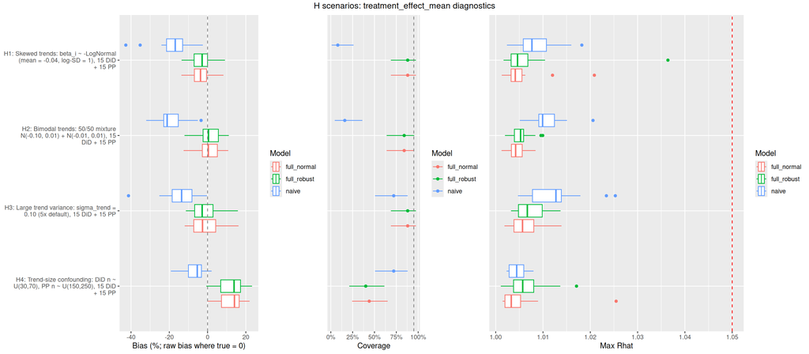

```r
plot_diagnostics(all_rep, all_agg, scenario_lookup_tbl, "H")
```

```r
results_table(all_agg, scenario_lookup_tbl, "H")
```

Category H: results

| Scenario | Description | Model | Fit | Parameter | Coverage | Bias | RMSE |
| --- | --- | --- | --- | --- | --- | --- | --- |
| H1 | Skewed trends: beta_i ~ -LogNormal (mean = -0.04, log-SD = 1), 15 DiD + 15 PP | normalised; normal heterogeneity; pooled trend; estimated imbalance | full_normal | time_trend_mean | 0.72 | 0.001 | 0.036 |
|  |  |  | full_normal | time_trend_sd | 0.44 | 0.010 | 0.098 |
|  |  |  | full_normal | treatment_effect_mean | 0.88 | -0.013 | 0.021 |
|  |  |  | full_normal | treatment_effect_sd | 0.60 | 0.025 | 0.035 |
|  |  |  | full_robust | time_trend_mean | 0.72 | 0.005 | 0.031 |
|  |  |  | full_robust | time_trend_sd | 0.44 | -0.010 | 0.060 |
|  |  |  | full_robust | treatment_effect_mean | 0.88 | -0.010 | 0.019 |
|  |  |  | full_robust | treatment_effect_sd | 0.92 | 0.014 | 0.024 |
|  |  |  | naive | time_trend_mean | 0.76 | 0.006 | 0.035 |
|  |  |  | naive | time_trend_sd | 0.52 | 0.001 | 0.082 |
|  |  |  | naive | treatment_effect_mean | 0.08 | -0.061 | 0.066 |
|  |  |  | naive | treatment_effect_sd | 0.04 | 0.080 | 0.117 |
| H2 | Bimodal trends: 50/50 mixture N(-0.10, 0.01) + N(-0.01, 0.01), 15 DiD + 15 PP |  | full_normal | time_trend_mean | 1.00 | 0.000 | 0.014 |
|  |  |  | full_normal | time_trend_sd | 1.00 | 0.012 | 0.017 |
|  |  |  | full_normal | treatment_effect_mean | 0.84 | 0.003 | 0.019 |
|  |  |  | full_normal | treatment_effect_sd | 0.84 | 0.015 | 0.022 |
|  |  |  | full_robust | time_trend_mean | 1.00 | 0.000 | 0.015 |
|  |  |  | full_robust | time_trend_sd | 1.00 | 0.012 | 0.017 |
|  |  |  | full_robust | treatment_effect_mean | 0.84 | 0.004 | 0.018 |
|  |  |  | full_robust | treatment_effect_sd | 0.88 | 0.009 | 0.017 |
|  |  |  | naive | time_trend_mean | 0.88 | 0.009 | 0.024 |
|  |  |  | naive | time_trend_sd | 1.00 | 0.017 | 0.022 |
|  |  |  | naive | treatment_effect_mean | 0.16 | -0.063 | 0.067 |
|  |  |  | naive | treatment_effect_sd | 0.00 | 0.067 | 0.069 |
| H3 | Large trend variance: sigma_trend = 0.10 (5x default), 15 DiD + 15 PP |  | full_normal | time_trend_mean | 0.84 | 0.005 | 0.050 |
|  |  |  | full_normal | time_trend_sd | 0.92 | 0.013 | 0.035 |
|  |  |  | full_normal | treatment_effect_mean | 0.88 | -0.005 | 0.024 |
|  |  |  | full_normal | treatment_effect_sd | 0.76 | 0.015 | 0.024 |
|  |  |  | full_robust | time_trend_mean | 0.84 | 0.004 | 0.050 |
|  |  |  | full_robust | time_trend_sd | 0.92 | 0.012 | 0.035 |
|  |  |  | full_robust | treatment_effect_mean | 0.88 | -0.005 | 0.023 |
|  |  |  | full_robust | treatment_effect_sd | 0.84 | 0.011 | 0.021 |
|  |  |  | naive | time_trend_mean | 0.96 | 0.001 | 0.054 |
|  |  |  | naive | time_trend_sd | 0.76 | 0.024 | 0.060 |
|  |  |  | naive | treatment_effect_mean | 0.72 | -0.046 | 0.055 |
|  |  |  | naive | treatment_effect_sd | 0.00 | 0.125 | 0.129 |
| H4 | Trend-size confounding: DiD n ~ U(30,70), PP n ~ U(150,250), 15 DiD + 15 PP |  | full_normal | time_trend_mean | 0.32 | -0.039 | 0.043 |
|  |  |  | full_normal | time_trend_sd | 0.84 | 0.009 | 0.017 |
|  |  |  | full_normal | treatment_effect_mean | 0.44 | 0.041 | 0.046 |
|  |  |  | full_normal | treatment_effect_sd | 0.48 | 0.025 | 0.033 |
|  |  |  | full_robust | time_trend_mean | 0.28 | -0.039 | 0.043 |
|  |  |  | full_robust | time_trend_sd | 0.84 | 0.010 | 0.017 |
|  |  |  | full_robust | treatment_effect_mean | 0.40 | 0.041 | 0.047 |
|  |  |  | full_robust | treatment_effect_sd | 0.68 | 0.019 | 0.028 |
|  |  |  | naive | time_trend_mean | 0.12 | -0.049 | 0.052 |
|  |  |  | naive | time_trend_sd | 0.88 | 0.005 | 0.015 |
|  |  |  | naive | treatment_effect_mean | 0.72 | -0.022 | 0.028 |
|  |  |  | naive | treatment_effect_sd | 0.24 | 0.030 | 0.033 |

## G. Bias Source Investigation

Category G probes the two systematic bias sources identified in the large-N results (Category F). It comprises two sub-investigations.

**G1–G5: Prior sensitivity (unnormalised model).** The unnormalised model showed a small positive bias (~0.6–0.9%) for a negative true effect, consistent with hierarchical shrinkage toward zero from the default `N(0, 10)` prior on `treatment_effect_mean`. G1–G5 vary the prior standard deviation from 1 to 100 (G3 replicates the default) to test whether the bias decreases monotonically as the prior becomes more diffuse.

**G6–G9: Jensen’s inequality (normalised model).** The normalised model showed ~1% systematic downward bias at 200 studies, consistent with Jensen’s inequality on the ratio estimator: because the model fits E[θ/baseline] rather than E[θ]/E[baseline], the convexity of the reciprocal function induces a negative shift proportional to between-study baseline variance. G6–G8 vary between-study baseline variation (`baseline_sd` = 0, 0.01, 0.10) to confirm that the bias tracks the Jensen term; G9 uses a very large control group (`n_control = 5000`) to test whether high within-study precision alone eliminates the bias.

```r
scenario_summary_table("G") |>
  kable(caption = "Category G: scenario definitions")
```

Category G: scenario definitions

| ID | Description | DGP overrides | Fit overrides |
| --- | --- | --- | --- |
| G1 | Prior sensitivity: effect/trend prior sd = 1 (unnormalised, 20 DiD) | (defaults) | normalise_by_baseline = [FALSE]; priors = [list(dist = “normal”, mean = 0, sd = 1), list(dist = “cauchy”, scale = 5), list(dist = “normal”, mean = 0, sd = 1), list(dist = “cauchy”, scale = 5), list(di… |
| G2 | Prior sensitivity: effect/trend prior sd = 5 (unnormalised, 20 DiD) | (defaults) | normalise_by_baseline = [FALSE]; priors = [list(dist = “normal”, mean = 0, sd = 5), list(dist = “cauchy”, scale = 5), list(dist = “normal”, mean = 0, sd = 5), list(dist = “cauchy”, scale = 5), list(di… |
| G3 | Prior sensitivity: effect/trend prior sd = 10 (default, unnormalised, 20 DiD) | (defaults) | normalise_by_baseline = [FALSE]; priors = [list(dist = “normal”, mean = 0, sd = 10), list(dist = “cauchy”, scale = 5), list(dist = “normal”, mean = 0, sd = 10), list(dist = “cauchy”, scale = 5), list(… |
| G4 | Prior sensitivity: effect/trend prior sd = 50 (unnormalised, 20 DiD) | (defaults) | normalise_by_baseline = [FALSE]; priors = [list(dist = “normal”, mean = 0, sd = 50), list(dist = “cauchy”, scale = 5), list(dist = “normal”, mean = 0, sd = 50), list(dist = “cauchy”, scale = 5), list(… |
| G5 | Prior sensitivity: effect/trend prior sd = 100 (unnormalised, 20 DiD) | (defaults) | normalise_by_baseline = [FALSE]; priors = [list(dist = “normal”, mean = 0, sd = 100), list(dist = “cauchy”, scale = 5), list(dist = “normal”, mean = 0, sd = 100), list(dist = “cauchy”, scale = 5), lis… |
| G6 | Jensen’s test: baseline_sd = 0, no between-study variation (200 DiD) | n_did = 200; baseline_sd = 0 | (defaults) |
| G7 | Jensen’s test: baseline_sd = 0.01, reduced variation (200 DiD) | n_did = 200; baseline_sd = 0.01 | (defaults) |
| G8 | Jensen’s test: baseline_sd = 0.10, amplified variation (200 DiD) | n_did = 200; baseline_sd = 0.1 | (defaults) |
| G9 | Jensen’s test: n_control = 5000, high within-study precision (200 DiD) | n_did = 200; n_control = 5000 | (defaults) |

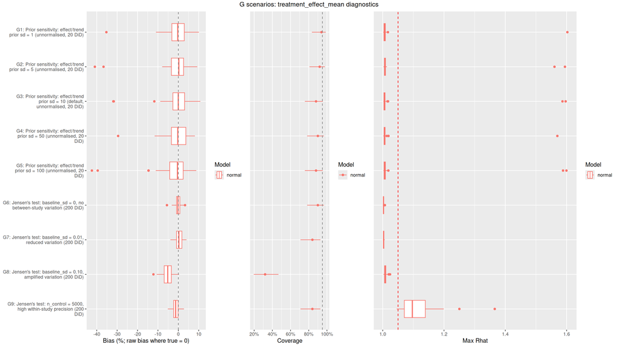

```r
plot_diagnostics(all_rep, all_agg, scenario_lookup_tbl, "G")
```

```r
results_table(all_agg, scenario_lookup_tbl, "G")
```

Category G: results

| Scenario | Description | Model | Fit | Parameter | Coverage | Bias | RMSE |
| --- | --- | --- | --- | --- | --- | --- | --- |
| G1 | Prior sensitivity: effect/trend prior sd = 1 (unnormalised, 20 DiD) | unnormalised; normal heterogeneity; pooled trend; estimated imbalance | default | baseline_control_mean | 0.82 | 0.000 | 0.020 |
|  |  |  | default | time_trend_mean | 0.96 | 0.002 | 0.009 |
|  |  |  | default | time_trend_sd | 0.94 | 0.001 | 0.004 |
|  |  |  | default | treatment_effect_mean | 0.94 | -0.001 | 0.010 |
|  |  |  | default | treatment_effect_sd | 0.86 | 0.000 | 0.007 |
| G2 | Prior sensitivity: effect/trend prior sd = 5 (unnormalised, 20 DiD) |  | default | baseline_control_mean | 0.84 | -0.002 | 0.026 |
|  |  |  | default | time_trend_mean | 0.96 | 0.002 | 0.012 |
|  |  |  | default | time_trend_sd | 0.92 | 0.000 | 0.004 |
|  |  |  | default | treatment_effect_mean | 0.92 | -0.002 | 0.013 |
|  |  |  | default | treatment_effect_sd | 0.90 | 0.000 | 0.007 |
| G3 | Prior sensitivity: effect/trend prior sd = 10 (default, unnormalised, 20 DiD) |  | default | baseline_control_mean | 0.82 | -0.004 | 0.029 |
|  |  |  | default | time_trend_mean | 0.88 | 0.000 | 0.011 |
|  |  |  | default | time_trend_sd | 0.90 | 0.002 | 0.005 |
|  |  |  | default | treatment_effect_mean | 0.88 | -0.001 | 0.012 |
|  |  |  | default | treatment_effect_sd | 0.96 | 0.001 | 0.006 |
| G4 | Prior sensitivity: effect/trend prior sd = 50 (unnormalised, 20 DiD) |  | default | baseline_control_mean | 0.80 | -0.002 | 0.021 |
|  |  |  | default | time_trend_mean | 0.88 | 0.001 | 0.011 |
|  |  |  | default | time_trend_sd | 0.86 | 0.001 | 0.005 |
|  |  |  | default | treatment_effect_mean | 0.90 | -0.001 | 0.010 |
|  |  |  | default | treatment_effect_sd | 0.88 | 0.003 | 0.008 |
| G5 | Prior sensitivity: effect/trend prior sd = 100 (unnormalised, 20 DiD) |  | default | baseline_control_mean | 0.90 | -0.002 | 0.025 |
|  |  |  | default | time_trend_mean | 0.90 | 0.003 | 0.013 |
|  |  |  | default | time_trend_sd | 0.90 | 0.001 | 0.005 |
|  |  |  | default | treatment_effect_mean | 0.88 | -0.004 | 0.014 |
|  |  |  | default | treatment_effect_sd | 0.88 | 0.000 | 0.006 |
| G6 | Jensen's test: baseline_sd = 0, no between-study variation (200 DiD) | normalised; normal heterogeneity; pooled trend; estimated imbalance | default | time_trend_mean | 0.88 | 0.000 | 0.004 |
|  |  |  | default | time_trend_sd | 0.84 | 0.002 | 0.003 |
|  |  |  | default | treatment_effect_mean | 0.90 | 0.000 | 0.006 |
|  |  |  | default | treatment_effect_sd | 0.84 | 0.001 | 0.005 |
| G7 | Jensen's test: baseline_sd = 0.01, reduced variation (200 DiD) |  | default | time_trend_mean | 0.90 | -0.001 | 0.004 |
|  |  |  | default | time_trend_sd | 0.94 | 0.001 | 0.003 |
|  |  |  | default | treatment_effect_mean | 0.84 | 0.001 | 0.006 |
|  |  |  | default | treatment_effect_sd | 0.90 | 0.001 | 0.005 |
| G8 | Jensen's test: baseline_sd = 0.10, amplified variation (200 DiD) |  | default | time_trend_mean | 0.62 | -0.006 | 0.007 |
|  |  |  | default | time_trend_sd | 0.12 | 0.011 | 0.013 |
|  |  |  | default | treatment_effect_mean | 0.32 | -0.018 | 0.020 |
|  |  |  | default | treatment_effect_sd | 0.00 | 0.052 | 0.054 |
| G9 | Jensen's test: n_control = 5000, high within-study precision (200 DiD) |  | default | time_trend_mean | 0.84 | -0.001 | 0.004 |
|  |  |  | default | time_trend_sd | 0.64 | 0.002 | 0.004 |
|  |  |  | default | treatment_effect_mean | 0.84 | -0.004 | 0.007 |
|  |  |  | default | treatment_effect_sd | 0.20 | 0.011 | 0.012 |

## Convergence Diagnostics

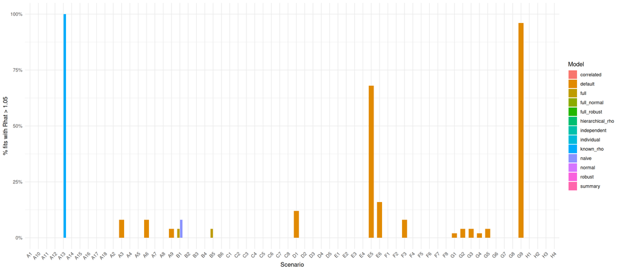

```r
plot_convergence(all_agg)
```

## Full Results Table

```r
all_agg |>
  arrange(scenario_id, model_label, parameter) |>
  kable(digits = 3, caption = "All aggregated results")
```

All aggregated results

| scenario_id | model_label | parameter | true_value | n_reps | empirical_coverage | mean_bias | median_bias | rmse | mean_ci_width | mean_posterior_sd | max_rhat_worst | min_ess_worst | pct_rhat_bad |
| --- | --- | --- | --- | --- | --- | --- | --- | --- | --- | --- | --- | --- | --- |
| A1 | default | time_trend_mean | -0.089 | 25 | 1.00 | -0.002 | -0.002 | 0.009 | 0.040 | 0.012 | 1.005 | 693.752 | 0.00 |
| A1 | default | time_trend_sd | 0.044 | 25 | 0.92 | 0.004 | 0.003 | 0.010 | 0.034 | 0.011 | 1.005 | 693.752 | 0.00 |
| A1 | default | treatment_effect_mean | -0.333 | 25 | 0.84 | 0.005 | 0.005 | 0.024 | 0.067 | 0.021 | 1.005 | 693.752 | 0.00 |
| A1 | default | treatment_effect_sd | 0.067 | 25 | 0.80 | 0.016 | 0.014 | 0.021 | 0.055 | 0.017 | 1.005 | 693.752 | 0.00 |
| A10 | default | baseline_control_mean | 0.450 | 25 | 0.96 | 0.001 | 0.004 | 0.011 | 0.044 | 0.014 | 1.008 | 512.627 | 0.00 |
| A10 | default | time_trend_mean | -0.040 | 25 | 0.84 | -0.003 | -0.002 | 0.008 | 0.023 | 0.007 | 1.008 | 512.627 | 0.00 |
| A10 | default | time_trend_sd | 0.020 | 25 | 0.96 | 0.000 | 0.002 | 0.006 | 0.021 | 0.007 | 1.008 | 512.627 | 0.00 |
| A10 | default | treatment_effect_mean | -0.150 | 25 | 0.84 | 0.003 | 0.003 | 0.009 | 0.026 | 0.008 | 1.008 | 512.627 | 0.00 |
| A10 | default | treatment_effect_sd | 0.030 | 25 | 0.80 | 0.000 | -0.001 | 0.007 | 0.021 | 0.006 | 1.008 | 512.627 | 0.00 |
| A11 | default | time_trend_mean | -0.089 | 25 | 0.92 | -0.003 | -0.004 | 0.010 | 0.040 | 0.012 | 1.005 | 811.086 | 0.00 |
| A11 | default | time_trend_sd | 0.044 | 25 | 0.96 | 0.004 | 0.004 | 0.009 | 0.034 | 0.011 | 1.005 | 811.086 | 0.00 |
| A11 | default | treatment_effect_mean | -0.333 | 25 | 0.96 | -0.006 | -0.006 | 0.019 | 0.070 | 0.021 | 1.005 | 811.086 | 0.00 |
| A11 | default | treatment_effect_sd | 0.067 | 25 | 0.56 | 0.020 | 0.023 | 0.027 | 0.058 | 0.018 | 1.005 | 811.086 | 0.00 |
| A12 | individual | time_trend_mean | -0.089 | 25 | 0.92 | -0.003 | -0.004 | 0.011 | 0.039 | 0.012 | 1.009 | 765.060 | 0.00 |
| A12 | individual | time_trend_sd | 0.044 | 25 | 0.92 | 0.002 | 0.003 | 0.010 | 0.034 | 0.010 | 1.009 | 765.060 | 0.00 |
| A12 | individual | treatment_effect_mean | -0.333 | 25 | 0.88 | -0.005 | -0.005 | 0.023 | 0.069 | 0.021 | 1.009 | 765.060 | 0.00 |
| A12 | individual | treatment_effect_sd | 0.067 | 25 | 0.64 | 0.019 | 0.022 | 0.027 | 0.057 | 0.018 | 1.009 | 765.060 | 0.00 |
| A12 | summary | time_trend_mean | -0.089 | 25 | 0.92 | -0.003 | -0.004 | 0.011 | 0.039 | 0.012 | 1.006 | 697.179 | 0.00 |
| A12 | summary | time_trend_sd | 0.044 | 25 | 0.88 | 0.002 | 0.003 | 0.010 | 0.033 | 0.010 | 1.006 | 697.179 | 0.00 |
| A12 | summary | treatment_effect_mean | -0.333 | 25 | 0.84 | -0.005 | -0.005 | 0.023 | 0.069 | 0.021 | 1.006 | 697.179 | 0.00 |
| A12 | summary | treatment_effect_sd | 0.067 | 25 | 0.60 | 0.019 | 0.021 | 0.027 | 0.057 | 0.018 | 1.006 | 697.179 | 0.00 |
| A13 | hierarchical_rho | time_trend_mean | -0.089 | 25 | 0.84 | -0.004 | -0.004 | 0.012 | 0.044 | 0.014 | 1.007 | 692.436 | 0.00 |
| A13 | hierarchical_rho | time_trend_sd | 0.044 | 25 | 0.68 | 0.010 | 0.010 | 0.017 | 0.037 | 0.012 | 1.007 | 692.436 | 0.00 |
| A13 | hierarchical_rho | treatment_effect_mean | -0.333 | 25 | 0.96 | 0.004 | 0.006 | 0.019 | 0.070 | 0.021 | 1.007 | 692.436 | 0.00 |
| A13 | hierarchical_rho | treatment_effect_sd | 0.067 | 25 | 0.64 | 0.020 | 0.016 | 0.025 | 0.057 | 0.018 | 1.007 | 692.436 | 0.00 |
| A13 | known_rho | time_trend_mean | -0.089 | 25 | 0.92 | -0.003 | -0.003 | 0.012 | 0.044 | 0.013 | 1.571 | 7.060 | 1.00 |
| A13 | known_rho | time_trend_sd | 0.044 | 25 | 0.64 | 0.010 | 0.010 | 0.016 | 0.037 | 0.012 | 1.571 | 7.060 | 1.00 |
| A13 | known_rho | treatment_effect_mean | -0.333 | 25 | 0.92 | 0.003 | 0.004 | 0.019 | 0.067 | 0.020 | 1.571 | 7.060 | 1.00 |
| A13 | known_rho | treatment_effect_sd | 0.067 | 25 | 0.60 | 0.020 | 0.017 | 0.025 | 0.056 | 0.017 | 1.571 | 7.060 | 1.00 |
| A14 | default | time_trend_mean | -0.089 | 25 | 0.92 | 0.003 | 0.003 | 0.010 | 0.041 | 0.012 | 1.007 | 700.107 | 0.00 |

[output cut: 334 more lines]